# R for Data Science: Wranglin’ II

September 28, 2016

## Wrangling Data II: Working with Text

## Strings

Strings are simply data in the form of characters rather than numbers. Still, they can be a bit trickier to deal with. The `stringr` package simplifies the process, and all of its commands begin with `str_` to make them a bit easier to remember.

```r
library(tidyverse)  # loads ggplot2, tibble, tidyr, readr,
                    # purrr, and dplyr
library(stringr)
```

## String Basics

`str_c()` combines two or more strings. Use the `sep` argument to define how the combined strings will be separated.

```r
days <- c("Sunday", "Monday", "Tuesday", "Wednesday",
          "Thursday", "Friday", "Saturday")
ordinals <- c("1st", "2nd", "3rd", "4th", "5th", "6th", "7th")

str_c(days, ", January ", ordinals, ", 2017")
```

```
## [1] "Sunday, January 1st, 2017"
## [2] "Monday, January 2nd, 2017"
## [3] "Tuesday, January 3rd, 2017"
## [4] "Wednesday, January 4th, 2017"
## [5] "Thursday, January 5th, 2017"
## [6] "Friday, January 6th, 2017"
## [7] "Saturday, January 7th, 2017"
```

## String Basics

`str_c()` combines two or more strings. Use the `sep` argument to define how the combined strings will be separated.

Use the `collapse` argument to combine the elements of a vector into a single string.

```r
str_c(days, collapse = "|")
```

```
## [1] "Sunday|Monday|Tuesday|Wednesday|Thursday|Friday|Saturday"
```

## String Basics

`str_sub()` subsets a string: you tell it where to start and stop.

```r
str_sub(days, start = 1, end = 1)
```

```
## [1] "S" "M" "T" "W" "T" "F" "S"
```

## String Basics

`str_sub()` subsets a string: you tell it where to start and stop. Use negative numbers to count from the end of the string.

[figure not shown]

```r
str_sub(days, start = -1, end = -1)
```

```
## [1] "y" "y" "y" "y" "y" "y" "y"
```

```r
# Oh, good!
```

## String Basics

- `str_to_lower()`, `str_to_upper()`, and `str_to_title()`
- `str_trim()` and `str_pad()`
- `str_length()`

## Regular Expressions

Regular expressions allow you to do some really superhuman things . . .

## Regular Expressions

Regular expressions allow you to do some really superhuman things . . .

[figure not shown]

## Regular Expressions

Regular expressions allow you to do some really superhuman things . . .

[figure not shown]

## Regular Expressions

Regular expressions allow you to do some really superhuman things . . .

[figure not shown]

## Regular Expressions

Regular expressions allow you to do some really superhuman things . . .

[figure not shown]

- Let’s get *you* this new, superhuman skill!

## Using Regular Expressions in R

- `str_detect()`: Does the regex pattern appear?
- `str_extract()` and `str_extract_all()`: Get the pattern
- `str_replace()` and `str_replace_all()`: Swap out the pattern
- `tidyr::separate()`: Break up the variable at the pattern

## Regular Expressions

- Every character matches itself

## Regular Expressions

- Every character matches itself

```r
str_detect(days, "T")
```

```
## [1] FALSE FALSE  TRUE FALSE  TRUE FALSE FALSE
```

## Regular Expressions

- Every character matches itself

```r
str_detect(days, "T") %>% which()
```

```
## [1] 3 5
```

## Regular Expressions: Basics

- Every character matches itself

```r
str_detect(days, "T") %>% which()
```

```
## [1] 3 5
```

```r
str_detect(days, "Th") %>% which()
```

```
## [1] 5
```

## Regular Expressions: Basics

- `.` : *Any* character (including spaces, etc.)

```r
str_extract(days, ".")
```

```
## [1] "S" "M" "T" "W" "T" "F" "S"
```

## Regular Expressions: Basics

- `.` : *Any* character (including spaces, etc.)

```r
str_extract_all(days, ".")
```

```
## [[1]]
## [1] "S" "u" "n" "d" "a" "y"
##
## [[2]]
## [1] "M" "o" "n" "d" "a" "y"
##
## [[3]]
## [1] "T" "u" "e" "s" "d" "a" "y"
##
## [[4]]
## [1] "W" "e" "d" "n" "e" "s" "d" "a" "y"
##
## [[5]]
## [1] "T" "h" "u" "r" "s" "d" "a" "y"
##
## [[6]]
## [1] "F" "r" "i" "d" "a" "y"
##
## [[7]]
## [1] "S" "a" "t" "u" "r" "d" "a" "y"
```

## Regular Expressions: Repetition

- `*` and `+` : *Greedy* repetition (0 or more and 1 or more)

```r
str_extract(days, ".*")
```

```
## [1] "Sunday"    "Monday"    "Tuesday"   "Wednesday"
## [5] "Thursday"  "Friday"    "Saturday"
```

## Regular Expressions: Repetition

- {2} : *Fixed* repetition, in this case 2 times

```r
str_extract(days, ".{2}")
```

```
## [1] "Su" "Mo" "Tu" "We" "Th" "Fr" "Sa"
```

## Regular Expressions: Repetition

- {7,} : *At least* repetition; here, at least 7 times

```r
str_extract(days, ".{7,}")
```

```
## [1] NA          NA          "Tuesday"   "Wednesday"
## [5] "Thursday"  NA          "Saturday"
```

## Regular Expressions: Repetition

- {7,} : *At least* repetition; here, at least 7 times

```r
str_extract(days, ".{7,}")
```

```
## [1] NA          NA          "Tuesday"   "Wednesday"
## [5] "Thursday"  NA          "Saturday"
```

```r
str_extract(days, ".{7,}") %>% str_length()
```

```
## [1] NA NA  7  9  8 NA  8
```

## Regular Expressions: Repetition

- {7,8} : *Between* repetition; here, at least 7 times but not more than 8

```r
str_extract(days, ".{7,8}")
```

```
## [1] NA         NA         "Tuesday"  "Wednesda" "Thursday"
## [6] NA         "Saturday"
```

```r
str_extract(days, ".{7,8}") %>% str_length()
```

```
## [1] NA NA  7  8  8 NA  8
```

## Regular Expressions: Optional Matches

- `?` : *Greedy* optional match (match 0 or 1 times, prefer 1)

```r
str_extract(days, ".at")
```

```
## [1] NA    NA    NA    NA    NA    NA    "Sat"
```

```r
str_extract(days, ".at?")
```

```
## [1] "da"  "da"  "da"  "da"  "da"  "da"  "Sat"
```

## Regular Expressions: Optional Matches

- `??` : *Lazy* optional match (match 0 or 1 times, prefer 0)

```r
str_extract_all(days, ".at?") %>% unlist() # unlist() just to fit slide
```

```
## [1] "da"  "da"  "da"  "da"  "da"  "da"  "Sat" "da"
```

```r
str_extract_all(days, ".at??") %>% unlist()
```

```
## [1] "da" "da" "da" "da" "da" "da" "Sa" "da"
```

## Regular Expressions: Repetition

- `*?` and `+?` : *Lazy* repetition (0 or more and 1 or more)

```r
str_extract(days, "a.+")
```

```
## [1] "ay"      "ay"      "ay"      "ay"      "ay"
## [6] "ay"      "aturday"
```

```r
str_extract(days, "a.+?")
```

```
## [1] "ay" "ay" "ay" "ay" "ay" "ay" "at"
```

## Regular Expressions: Anchors

- `^` and `$` : The beginning and end of the string

```r
str_extract(days, ".a.")
```

```
## [1] "day" "day" "day" "day" "day" "day" "Sat"
```

```r
str_extract(days, "^.a.")
```

```
## [1] NA    NA    NA    NA    NA    NA    "Sat"
```

```r
str_extract(days, ".a.$")
```

```
## [1] "day" "day" "day" "day" "day" "day" "day"
```

## Regular Expressions: Character Classes

- Okay, so I’m a fifth-level half-elven ranger, and

## Regular Expressions: Character Classes

- Okay, so I’m a fifth-level half-elven ranger, and

Sorry

## Regular Expressions: Character Classes

- Make your own wildcard with `[` and `]`!

```r
str_extract(days, ".[aeiou]") # any character & then a lowercase vowel
```

```
## [1] "Su" "Mo" "Tu" "We" "hu" "ri" "Sa"
```

## Regular Expressions: Character Classes

- Within a character class, `^` means *not*

```r
str_extract(days, ".[^aeiou]") # any character & then one NOT a lc vowel
```

```
## [1] "un" "on" "es" "ed" "Th" "Fr" "at"
```

## Regular Expressions: Character Classes

```r
str_extract(c("hi", "324"), "\\d+") # \\d: digit
```

```
## [1] NA    "324"
```

```r
str_extract(days, "\\D") # \\D: not a digit
```

```
## [1] "S" "M" "T" "W" "T" "F" "S"
```

```r
# \\w: 'word' [A-Za-z0-9_]; \\W: not word
str_detect(c("123", "abc", ", "), "\\W")
```

```
## [1] FALSE FALSE  TRUE
```

## Regular Expressions: Character Classes

```r
# \\b: boundary
str_detect(c("dog", "dog is good",
             "dogs are bad", "doggy is bad too"), "dog\\b")
```

```
## [1]  TRUE  TRUE FALSE FALSE
```

```r
# \\s: whitespace
str_detect(c("dog", "dog is good",
             "dogs are bad", "doggy is bad too"), "\\s")
```

```
## [1] FALSE  TRUE  TRUE  TRUE
```

## Regular Expressions: Capture Groups

- Parentheses remember the match within them to use later

```r
str_replace(days, "([aeiou])", "\\1\\1\\1")
```

```
## [1] "Suuunday"    "Mooonday"    "Tuuuesday"   "Weeednesday"
## [5] "Thuuursday"  "Friiiday"    "Saaaturday"
```

- What will this do?

```r
str_replace(days, "([aeiou])(.*)([aeiou])", "\\3\\2\\1")
```

## Regular Expressions: Capture Groups

- Parentheses remember the match within them to use later

```r
str_replace(days, "([aeiou])", "\\1\\1\\1")
```

```
## [1] "Suuunday"    "Mooonday"    "Tuuuesday"   "Weeednesday"
## [5] "Thuuursday"  "Friiiday"    "Saaaturday"
```

- What will this do?

```r
str_replace(days, "([aeiou])(.*)([aeiou])", "\\3\\2\\1")
```

```
## [1] "Sanduy"    "Mandoy"    "Taesduy"   "Wadnesdey"
## [5] "Tharsduy"  "Fradiy"    "Saturday"
```

## Regular Expressions: Capture Groups

- With *greedy* repetition, we match first and *last* vowels

```r
str_replace(days, "([aeiou])(.*)([aeiou])", "\\3\\2\\1")
```

```
## [1] "Sanduy"    "Mandoy"    "Taesduy"   "Wadnesdey"
## [5] "Tharsduy"  "Fradiy"    "Saturday"
```

- With *lazy* repetition, we matches first and *second* vowels

```r
str_replace(days, "([aeiou])(.*?)([aeiou])", "\\3\\2\\1")
```

```
## [1] "Sanduy"    "Mandoy"    "Teusday"   "Wednesday"
## [5] "Tharsduy"  "Fradiy"    "Sutarday"
```

## Regular Expressions: Capture Groups

- Capture groups can be nested: the count goes with the opening paren

```r
monster_truck_days <- str_replace(days, "(.*(day))",
                                  "\\1\\1\\1\\2\\2\\2")
monster_truck_days
```

```
## [1] "SundaySundaySundaydaydayday"
## [2] "MondayMondayMondaydaydayday"
## [3] "TuesdayTuesdayTuesdaydaydayday"
## [4] "WednesdayWednesdayWednesdaydaydayday"
## [5] "ThursdayThursdayThursdaydaydayday"
## [6] "FridayFridayFridaydaydayday"
## [7] "SaturdaySaturdaySaturdaydaydayday"
```

## Regular Expressions: Capture Groups

- Capture groups also allow you to apply repetition, etc., to whole group

```r
str_detect(monster_truck_days, "(day){3}")
```

```
## [1] TRUE TRUE TRUE TRUE TRUE TRUE TRUE
```

## Regular Expressions: An Example

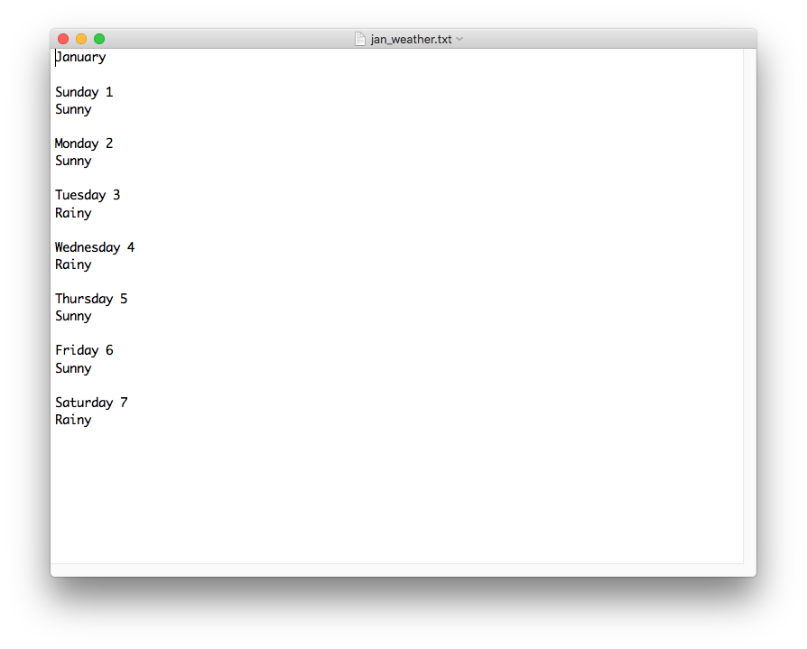

## Regular Expressions: An Example

```r
weather <- readLines("cmcr05_files/jan_weather.txt")
weather
```

```
##  [1] "January"     ""            "Sunday 1"    "Sunny"
##  [5] ""            "Monday 2"    "Sunny"       ""
##  [9] "Tuesday 3"   "Rainy"       ""            "Wednesday 4"
## [13] "Rainy"       ""            "Thursday 5"  "Sunny"
## [17] ""            "Friday 6"    "Sunny"       ""
## [21] "Saturday 7"  "Rainy"
```

## Regular Expressions: An Example

```r
day_pattern <- str_c(days, collapse = "|")
weather_df <- weather %>%
    tibble(text = .,
           day_date = if_else(str_detect(text, day_pattern),
                              text,
                              NA_character_)) %>%
    filter(!(str_detect(text, "^\\s*$")))
weather_df
```

```
## # A tibble: 15 x 2
##    text        day_date
##    <chr>       <chr>
##  1 January     <NA>
##  2 Sunday 1    Sunday 1
##  3 Sunny       <NA>
##  4 Monday 2    Monday 2
##  5 Sunny       <NA>
##  6 Tuesday 3   Tuesday 3
##  7 Rainy       <NA>
##  8 Wednesday 4 Wednesday 4
##  9 Rainy       <NA>
## 10 Thursday 5  Thursday 5
## 11 Sunny       <NA>
## 12 Friday 6    Friday 6
## 13 Sunny       <NA>
## 14 Saturday 7  Saturday 7
## 15 Rainy       <NA>
```

## Regular Expressions: An Example

```r
weather_df <- weather_df %>%
    fill(day_date) %>%      # from tidyr: fills na with last observed value
    filter(text!=day_date) %>%
    separate(day_date, into = c("day", "date"), sep = " ")
weather_df
```

```
## # A tibble: 7 x 3
##   text  day       date
##   <chr> <chr>     <chr>
## 1 Sunny Sunday    1
## 2 Sunny Monday    2
## 3 Rainy Tuesday   3
## 4 Rainy Wednesday 4
## 5 Sunny Thursday  5
## 6 Sunny Friday    6
## 7 Rainy Saturday  7
```